# Tilastollinen Oppimisen Jatkokurssi Round 4

## Exercise 1

*ISLR 9.2: We have seen that in p = 2 dimensions, a linear decision boundary takes the form β0+β1X1+β2X2 = 0. We now investigate a non-linear decision boundary.*

#### (a)

*Sketch the curve*
$$(1+X_1)^2 + (2-X_2)^2 = 4.$$

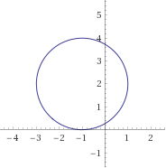

#### (b)

*On your sketch, indicate the set of points for which*
$$(1+X_1)^2 + (2-X_2)^2 > 4,$$
*as well as the set of points for which*
$$(1+X_1)^2 + (2-X_2)^2 \leq 4.$$

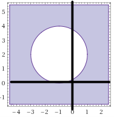

The points in blue are the first ones, the points in white the second ones

#### (c)

*Suppose that a classifier assigns an observation to the blue class if*
$$(1+X_1)^2 + (2-X_2)^2 > 4,$$
*and to the red class otherwise. To what class is the observation (0, 0) classified? (−1, 1)? (2, 2)? (3, 8)?*

(0, 0) -> Blue (-1, 1) -> Red (2, 2) -> Blue (3, 8) -> Blue

#### (d)

*Argue that while the decision boundary in (c) is not linear in terms of X1 and X2, it is linear in terms of $X_1$, $X_2^1$, $X_2$, and $X_2^2$.*

Observe that (0, 0) and (0, 4) are both classified as blue but (0, 2) which is on the line from (0, 0) to (0, 4) is classified as red. Thus the boundary can not be linear in terms of X1 only X1 and X2. Expanding the equation and setting $X_3=X_1^2$ and $X_4=X_2^2$ we get
$$4=(1+X_1)^2 + (2-X_2)^2=1+2X_1+X_1^2+4-4X_2+X^2_2=1+2X_1-4X_2+X_3+X_4=4$$
as the decision boundary. This is a linear decision boundary.

## Exercise 2

*ISLR 9.3: Here we explore the maximal margin classifier on a toy data set*

#### (a)

*We are given n = 7 observations in p = 2 dimensions. For each observation, there is an associated class label. Sketch the observations.*

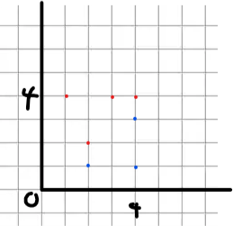

Sketch

#### (b)

*Sketch the optimal separating hyperplane, and provide the equation for this hyperplane (of the form (9.1)).*

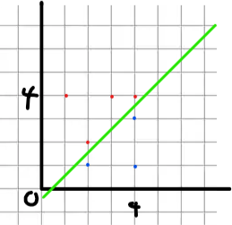

Optimal separatin hyperplane in green.

$$\beta_0 + \beta_1X_1 + \beta_2X_2 = 0 = 0.5 - X_1 + X_2.$$

#### (c)

*Describe the classification rule for the maximal margin classifier. It should be something along the lines of “Classify to Red if β0 + β1X1 + β2X2 > 0, and classify to Blue otherwise.” Provide the values for β0, β1, and β2.*

Classify Red if
$$\beta_0 + \beta_1X_1 + \beta_2X_2 = 0.5 - X_1 + X_2 > 0,$$
Blue otherwise. $\beta_0 = 0.5,~\beta_1 = -1,~\beta_2 = 1$.

#### (d)

*On your sketch, indicate the margin for the maximal margin hyperplane.*

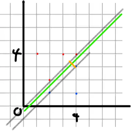

Margin (or two times the margin in orange).

#### (e)

*Indicate the support vectors for the maximal margin classifier*

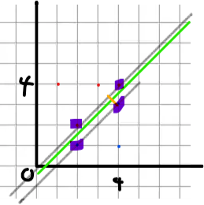

Support vectors indicated by purple.

#### (f)

*Argue that a slight movement of the seventh observation would not affect the maximal margin hyperplane.*

The seventh observation (4, 1) is far from the separating hyperplane and not a support vector. Moving it at most a duistance of $\sqrt{2}$ will not change the optimal separating hyperplane.

#### (g)

*Sketch a hyperplane that is not the optimal separating hyperplane, and provide the equation for this hyperplane.*

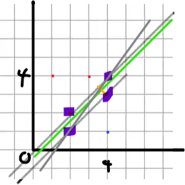

In gray.

#### (h)

*Draw an additional observation on the plot so that the two classes are no longer separable by a hyperplane.*

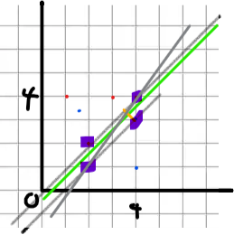

Blue observation in the middle of the red ones.

## Exercise 3

*ISLR 9.5: We have seen that we can fit an SVM with a non-linear kernel in order to perform classification using a non-linear decision boundary. We will now see that we can also obtain a non-linear decision boundary by performing logistic regression using non-linear transformations of the features.*

#### (a)

*Generate a data set with n = 500 and p = 2, such that the observations belong to two classes with a quadratic decision boundary between them. For instance, you can do this as follows:*

```r
set.seed(92)
x1 = runif(500) - 0.5
x2 = runif(500) - 0.5
y = 1 * (x1^2 - x2^2 > 0)
train = data.frame(y, x1, x2)
```

#### (b)

*Plot the observations, colored according to their class labels. Your plot should display X1 on the x-axis, and X2 on the yaxis.*

```r
plot(x = train$x1[y == 1], y = train$x2[y == 1], type = "p", col = "red", xlim = c(-0.5, 0.5), ylim = c(-0.5, 0.5))
points(x = train$x1[y == 0], y = train$x2[y == 0], col = "blue")
```

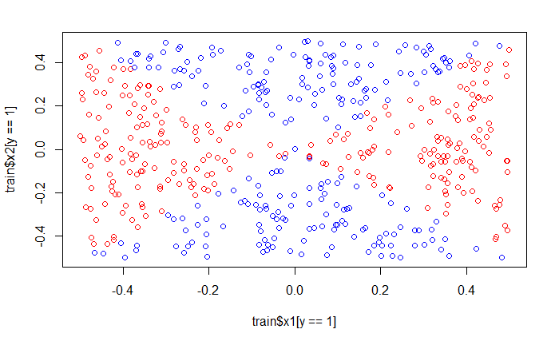

#### (c)

*Fit a logistic regression model to the data, using X1 and X2 as predictors.*

```r
fit.loglinear = glm(y ~ x1 + x2, family=binomial(link='logit'), data = train)
```

#### (d)

*Apply this model to the training data in order to obtain a predicted class label for each training observation. Plot the observations, colored according to the predicted class labels. The decision boundary should be linear.*

```r
fit.loglinear.pred = predict(fit.loglinear, data = train, type = "response")
train$pred = 1 * (fit.loglinear.pred < 0.5)
plot(x = train$x1[train$pred == 1], y = train$x2[train$pred == 1], type = "p", col = "red", xlim = c(-0.5, 0.5), ylim = c(-0.5, 0.5))
points(x = train$x1[train$pred == 0], y = train$x2[train$pred == 0], col = "blue")
```

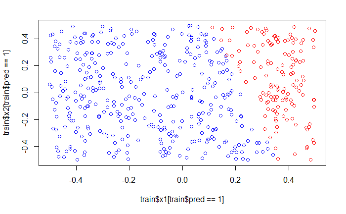

#### (e)

*Now fit a logistic regression model to the data using non-linear functions of X1 and X2 as predictors (e.g. X2 1 , X1×X2, log(X2), and so forth).*

```r
train$x12 = train$x1*train$x1
train$x22 = train$x2*train$x2
train$cross = train$x1*train$x2
fit.lognon = glm(y ~ x1 + x2 + x12 + x22 + cross, family=binomial(link='logit'), data = train)
```

```
glm.fit: algorithm did not convergeglm.fit: fitted probabilities numerically 0 or 1 occurred
```